# This is the principal preeliminar notebook for data analysis and deployment

Created at 06/2024

Este es un proyecto preeliminar, que servirá como base para desarrollar una aplicación interactiva para el análisis de las anomalias dentro del mercado búrsatil, de momento he utilizado como interés para el anásilis las acciones de las principales grandes compañías relacionadas a la IA, su desarrollo, implementación y hardware.

## Data mining using yfinance & pandas

```python
import pandas as pd
import yfinance as yf
from datetime import date, timedelta
```

```python
data = None
end_date = date.today().strftime('%Y-%m-%d')
start_date = (date.today() - timedelta(days=365)).strftime('%Y-%m-%d')

tickers = ['MSFT','GOOGL','TSLA','NVDA','TSM']

data = yf.download(tickers=tickers, group_by='Ticker', period='2y', progress=False)
data = data.stack(level=0).rename_axis(['Date', 'Ticker']).reset_index(level=1)
```

```python
stock_data = data.reset_index()
stock_data['Date'] = pd.to_datetime(stock_data['Date'])
stock_data.set_index('Date', inplace=True)
stock_data
```

| Price Date | Ticker | Open | High | Low | Close | Adj Close | Volume |
| --- | --- | --- | --- | --- | --- | --- | --- |
| 2022-06-29 | GOOGL | 111.552002 | 113.160500 | 110.872498 | 111.701500 | 111.573448 | 24716000 |
| 2022-06-29 | MSFT | 257.589996 | 261.970001 | 255.759995 | 260.260010 | 255.767593 | 20069800 |
| 2022-06-29 | NVDA | 15.814000 | 15.820000 | 15.170000 | 15.542000 | 15.524516 | 482352000 |
| 2022-06-29 | TSLA | 230.500000 | 231.173340 | 222.273331 | 228.490005 | 228.490005 | 82897200 |
| 2022-06-29 | TSM | 84.430000 | 84.610001 | 83.330002 | 83.650002 | 80.551529 | 7981300 |
| ... | ... | ... | ... | ... | ... | ... | ... |
| 2024-06-28 | GOOGL | 184.320007 | 185.130005 | 181.960007 | 182.149994 | 182.149994 | 29149300 |
| 2024-06-28 | MSFT | 453.070007 | 455.380005 | 446.410004 | 446.950012 | 446.950012 | 28333300 |
| 2024-06-28 | NVDA | 124.580002 | 127.709999 | 122.750000 | 123.540001 | 123.540001 | 314945500 |
| 2024-06-28 | TSLA | 199.550003 | 203.199997 | 195.259995 | 197.880005 | 197.880005 | 95302700 |
| 2024-06-28 | TSM | 172.809998 | 176.820007 | 172.809998 | 173.809998 | 173.809998 | 11203600 |

2515 rows × 7 columns

## Exploratory Data Analysis

```python
import matplotlib.pyplot as plt
import seaborn as sns
```

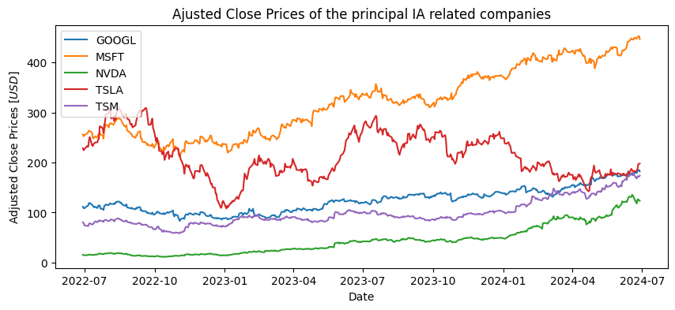

```python
plt.figure(figsize=(10,4))

for tick in stock_data['Ticker'].unique():
    subset = stock_data[stock_data['Ticker']==tick]
    plt.plot(subset.index, subset['Adj Close'], label=tick)

plt.title('Ajusted Close Prices of the principal IA related companies')
plt.xlabel('Date')
plt.ylabel('Adjusted Close Prices [$USD$]')
plt.legend()
plt.show()
```

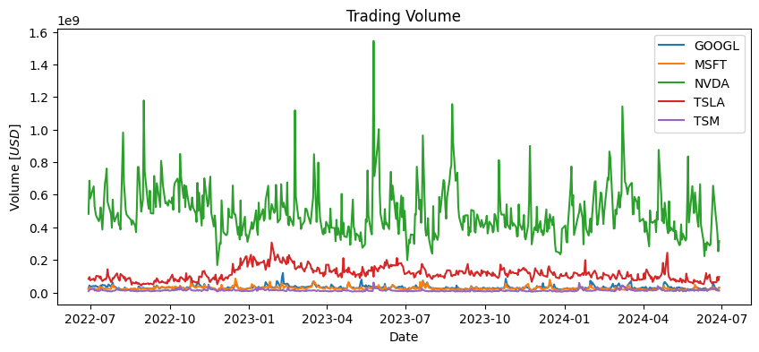

```python
plt.figure(figsize=(10,4))

for tick in stock_data['Ticker'].unique():
    subset = stock_data[stock_data['Ticker']==tick]
    plt.plot(subset.index, subset['Volume'], label=tick)

plt.title('Trading Volume')
plt.xlabel('Date')
plt.ylabel('Volume [$USD$]')
plt.legend()
plt.show()
```

## ML model to detect market anomalies

Cuando analizamos datos financieros, es crucial identificar anomalías que puedan afectar nuestras decisiones. Dos aspectos clave a considerar son los movimientos de precios y los volúmenes de negociación.

1. Movimientos de Precios Significativos:  
   Observamos si los precios de cierre ajustados se desvían significativamente del rango o tendencia típica de la acción.  
   Si un precio está muy por encima o por debajo de lo esperado, podría ser una señal de anomalía.
2. Volúmenes de Negociación Inusuales: Examinamos los volúmenes de negociación para detectar actividad inusual. Si el volumen es mucho mayor o menor de lo habitual, es importante investigar más a fondo.

Para identificar estas anomalías, utilizamos el método Z-score. Este método compara cada punto de datos con la media y mide cuántas desviaciones estándar se encuentra ese punto. Un umbral común para detectar anomalías es una puntuación Z mayor que 2 o menor que -2, lo que indica que el dato está a más de 2 desviaciones estándar de la media.

En resumen, calculamos las puntuaciones Z tanto para los precios de cierre ajustados como para los volúmenes de negociación de cada acción. Cualquier punto de datos que supere este umbral merece una atención especial. 📈🔍

```python
from scipy.stats import zscore

def detect_anomalies(df, column):
    df_copy = df.copy()
    df_copy['Z_score'] = zscore(df_copy[column])

    anomalies = df_copy[abs(df_copy['Z_score'])>2]
    return anomalies

anomalies_adj_close = pd.DataFrame()
anomalies_volume = pd.DataFrame()

for tick in stock_data['Ticker'].unique():
    data_ticker = stock_data[stock_data['Ticker']==tick]

    adj_close_anomalies = detect_anomalies(data_ticker,'Adj Close')
    volume_anomalies = detect_anomalies(data_ticker, 'Volume')

    anomalies_adj_close = pd.concat([anomalies_adj_close,adj_close_anomalies])
    anomalies_volume = pd.concat([anomalies_volume,volume_anomalies])

anomalies_adj_close
```

| Price Date | Ticker | Open | High | Low | Close | Adj Close | Volume | Z_score |
| --- | --- | --- | --- | --- | --- | --- | --- | --- |
| 2024-05-15 | GOOGL | 170.630005 | 172.649994 | 170.509995 | 172.509995 | 172.312241 | 26948400 | 2.001994 |
| 2024-05-16 | GOOGL | 173.289993 | 175.119995 | 172.690002 | 174.179993 | 173.980316 | 27867900 | 2.070859 |
| 2024-05-17 | GOOGL | 174.179993 | 176.270004 | 173.690002 | 176.059998 | 175.858170 | 24479300 | 2.148385 |
| 2024-05-20 | GOOGL | 176.190002 | 178.770004 | 176.080002 | 176.919998 | 176.717178 | 22554400 | 2.183848 |
| 2024-05-21 | GOOGL | 176.899994 | 178.149994 | 175.809998 | 177.850006 | 177.646118 | 16989400 | 2.222198 |
| ... | ... | ... | ... | ... | ... | ... | ... | ... |
| 2024-06-24 | TSM | 170.429993 | 171.419998 | 167.119995 | 167.809998 | 167.809998 | 19741700 | 2.658863 |
| 2024-06-25 | TSM | 169.949997 | 172.639999 | 169.009995 | 172.600006 | 172.600006 | 13481000 | 2.843004 |
| 2024-06-26 | TSM | 172.119995 | 173.690002 | 170.199997 | 172.070007 | 172.070007 | 11901500 | 2.822629 |
| 2024-06-27 | TSM | 173.789993 | 175.479996 | 171.149994 | 171.630005 | 171.630005 | 10864600 | 2.805714 |
| 2024-06-28 | TSM | 172.809998 | 176.820007 | 172.809998 | 173.809998 | 173.809998 | 11203600 | 2.889519 |

109 rows × 8 columns

### Now we need to plot the anomalies

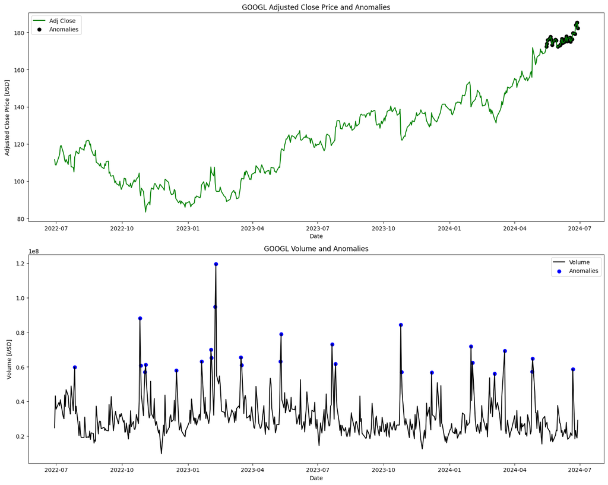

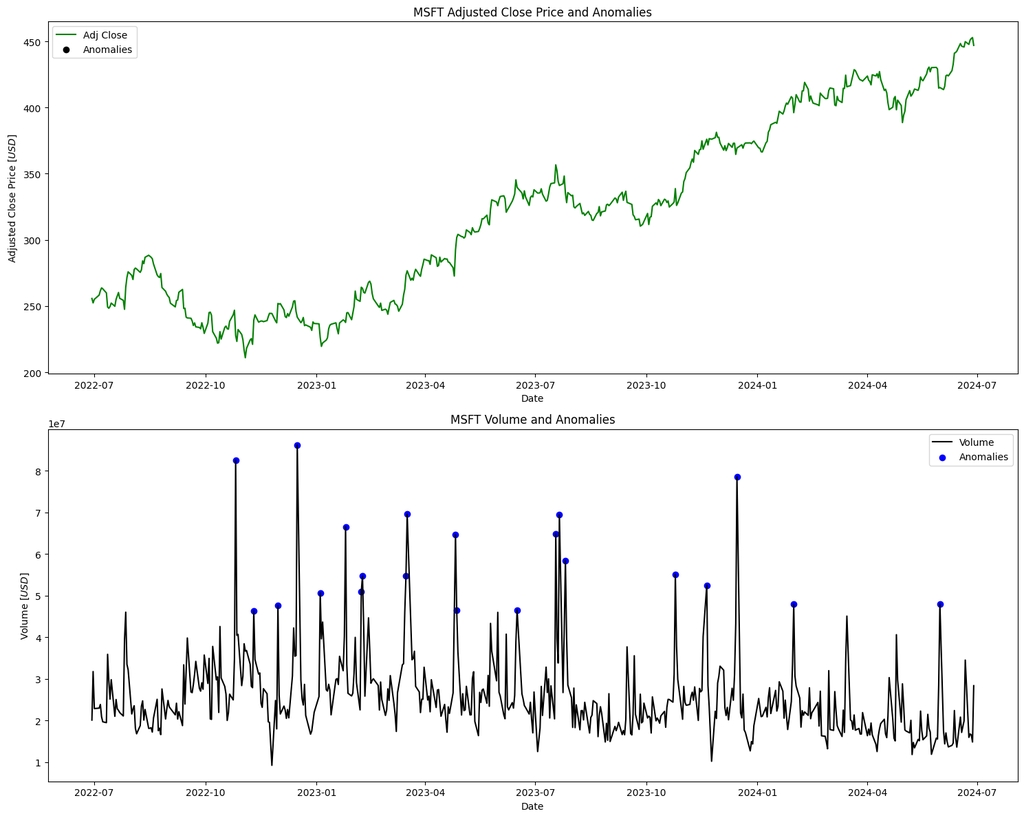

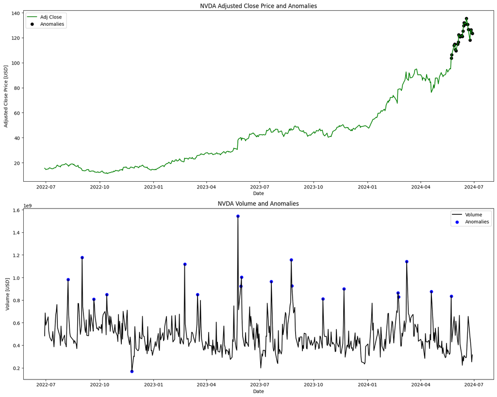

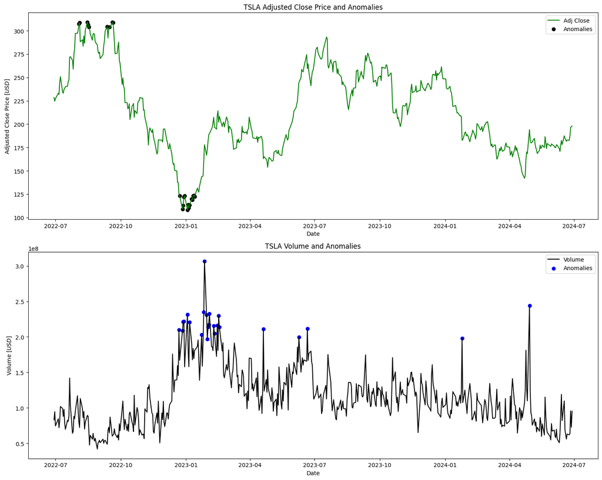

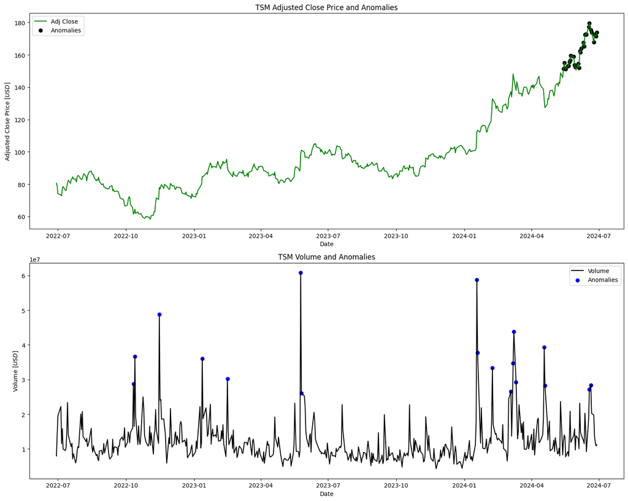

```python
def plot_anomalies(ticker, anomalies_adj_close, anomalies_volume):
    # Filter tho main and anomalies data for ticker
    data_ticker = stock_data[stock_data['Ticker']==ticker]
    adj_close_anomalies = anomalies_adj_close[anomalies_adj_close['Ticker']==ticker]
    volume_anomalies = anomalies_volume[anomalies_volume['Ticker'] == ticker]

    fig, (ax1, ax2) = plt.subplots(2,1, figsize=(15,12))
    ax1.plot(data_ticker.index, data_ticker['Adj Close'], label='Adj Close', color = 'green')
    ax1.scatter(adj_close_anomalies.index, adj_close_anomalies['Adj Close'], label = 'Anomalies', color = 'black')
    ax1.set_title(f'{ticker} Adjusted Close Price and Anomalies')
    ax1.set_xlabel('Date')
    ax1.set_ylabel('Adjusted Close Price [$USD$]')
    ax1.legend()


    ax2.plot(data_ticker.index, data_ticker['Volume'], label='Volume', color='black')
    ax2.scatter(volume_anomalies.index, volume_anomalies['Volume'], label ='Anomalies', color='Blue')
    ax2.set_title(f'{ticker} Volume and Anomalies')
    ax2.set_xlabel('Date')
    ax2.set_ylabel('Volume [$USD$]')
    ax2.legend()

    plt.tight_layout()
    plt.show()

for tickers in stock_data['Ticker'].unique():
    plot_anomalies(tickers,anomalies_adj_close,anomalies_volume)
```

## Analizing correlations and risks

```python
all_anomalies_adj_close = anomalies_adj_close[['Ticker']].copy()
all_anomalies_adj_close['Adj Close Anomaly'] = 1

all_anomalies_volume = anomalies_volume[['Ticker']].copy()
all_anomalies_volume['Volume Anomaly'] = 1

adj_close_pivot = all_anomalies_adj_close.pivot_table(index=all_anomalies_adj_close.index, columns='Ticker', fill_value=0, aggfunc='sum')
volume_pivot = all_anomalies_volume.pivot_table(index=all_anomalies_volume.index, columns='Ticker', fill_value=0, aggfunc='sum')

adj_close_pivot.columns = adj_close_pivot.columns.get_level_values(1)
volume_pivot.columns = volume_pivot.columns.get_level_values(1)

combined_anomalies = pd.concat([adj_close_pivot,volume_pivot], axis=1, keys=['Adj Close Anomaly', 'Volume Anomaly'])

correlation_matrix = combined_anomalies.corr()
print(correlation_matrix)
```

```
                         Adj Close Anomaly                                \
Ticker                               GOOGL      NVDA      TSLA       TSM
                  Ticker
Adj Close Anomaly GOOGL           1.000000  0.760000 -0.928709  0.890235
                  NVDA            0.760000  1.000000 -0.773924  0.729591
                  TSLA           -0.928709 -0.773924  1.000000 -0.963528
                  TSM             0.890235  0.729591 -0.963528  1.000000
Volume Anomaly    GOOGL           0.356753  0.356753 -0.356753  0.426401
                  MSFT            0.075593  0.075593 -0.075593 -0.316228
                  NVDA            0.356753  0.356753 -0.356753  0.426401
                  TSLA           -0.714286 -0.714286  0.714286 -0.597614
                  TSM             0.292770  0.292770 -0.292770  0.408248

                         Volume Anomaly                                \
Ticker                            GOOGL      MSFT      NVDA      TSLA
                  Ticker
Adj Close Anomaly GOOGL        0.356753  0.075593  0.356753 -0.714286
                  NVDA         0.356753  0.075593  0.356753 -0.714286
                  TSLA        -0.356753 -0.075593 -0.356753  0.714286
                  TSM          0.426401 -0.316228  0.426401 -0.597614
Volume Anomaly    GOOGL        1.000000  0.158114 -0.228543 -0.224966
                  MSFT         0.158114  1.000000 -0.164731 -0.327815
                  NVDA        -0.228543 -0.164731  1.000000 -0.317654
                  TSLA        -0.224966 -0.327815 -0.317654  1.000000
                  TSM         -0.262137 -0.271979  0.002928 -0.297196


Ticker                         TSM
                  Ticker
Adj Close Anomaly GOOGL   0.292770
                  NVDA    0.292770
                  TSLA   -0.292770
                  TSM     0.408248
Volume Anomaly    GOOGL  -0.262137
                  MSFT   -0.271979
                  NVDA    0.002928
                  TSLA   -0.297196
                  TSM     1.000000
```

Adj Close Anomaly:

La correlación entre las anomalías de precios de cierre ajustados de GOOGL y NVDA es 0.76, lo que sugiere una relación positiva moderada.  
La correlación entre las anomalías de precios de cierre ajustados de GOOGL y TSLA es -0.93, lo que indica una fuerte relación negativa.  
La correlación entre las anomalías de precios de cierre ajustados de TSLA y TSM es -0.96, lo que también sugiere una fuerte relación negativa.

### Analyzing the risk of anomalies

We can aproach the risk of anomalies by:

1. Frecuency of anomalies
2. Magnitude of anomalies

```python
adj_close_risk = anomalies_adj_close.groupby('Ticker')['Z_score'].apply(lambda x : abs(x).mean())
volume_risk = anomalies_volume.groupby('Ticker')['Z_score'].apply(lambda x: abs(x).mean())

total_risk = adj_close_risk + volume_risk

risk_rating = (total_risk - total_risk.min())/ (total_risk.max() - total_risk.min())
risk_rating
```

```
Ticker
GOOGL    0.317238
MSFT          NaN
NVDA     0.689752
TSLA     0.000000
TSM      1.000000
Name: Z_score, dtype: float64
```